# Comparing Website Generators Over Time

Peter Baumgartner

2019-08-01

# Introduction

This article is the follow-up of [Retrieving And Scrapping Archived Data With The Wayback Machine](https://rpubs.com/pbaumgartner/wayback). Here I will display some results from the scrapped archived web site https://www.staticgen.com/ at seven dates, starting from May 2014 to August 2019.

# Setup

```r
knitr::opts_chunk$set(
        message = F,
        error = F,
        warning = F,
        comment = NA,
        highlight = T,
        prompt = T
        )
### Set the global option options(stringsAsFactors = FALSE)
### inside a parent function and restore the option after the parent function exits
if (!require("xfun"))
        {install.packages("xfun", repos = 'http://cran.wu.ac.at/')
        library(xfun)}
xfun::stringsAsStrings()

### install and load some important packages
### https://github.com/tidyverse/tidyverse
if (!require("tidyverse"))
        {install.packages("tidyverse", repos = 'http://cran.wu.ac.at/')
        library(tidyverse)}
# lubridate, for date/times.
if (!require("lubridate"))
        {install.packages("lubridate", repos = 'http://cran.wu.ac.at/')
        library(lubridate)}
# reshape2, restructure and aggregate data using melt and dcast
if (!require("reshape2"))
        {install.packages("reshape2", repos = 'http://cran.wu.ac.at/')
        library(reshape2)}
```

# Introduction

My analysis will concentrate on three issues:

1. Development of the number of static web site generators as displayed by the website https://www.staticgen.com/.
2. Name of static website generators ranked by the number of stars for their repositories as a proxy for their popularity.
3. Relative rankings of 18 website generators among each other at seven different dates.

Other data (the number of forks, open issues, and followers on twitter) are not analyzed. They have, in my opinion, only a weak relationship with the diffusion of the web site generator. Perhaps the exclusion of twitter followers needs more reflection:

- The display of the number of twitter followers started only around 2019.
- As today (2019-07-31) only 37 static website generators have a twitter account.
- Even leading static website frameworks (e.g., Next.js) have no twitter account.
- The number of followers results not only from the popularity of the generator but also from exciting and well-written tweeds.

# Growth of the Popularity of Static Websites Generators

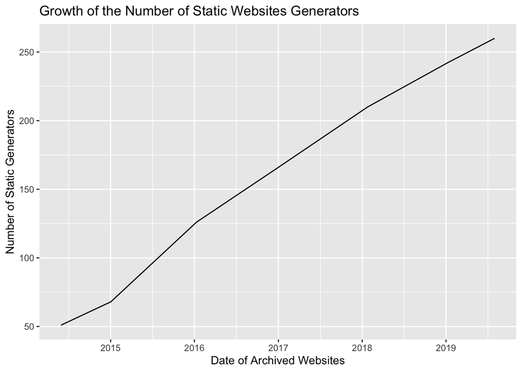

```r
> sg_count = NULL
> for (i in 1:length(sg_data_collection)) {
+   sg_count[i] <- nrow(sg_data_collection[[i]])
+ }
> sg_quantity <- data.frame(cbind(sg_crawllist[2], sg_count))
> sg_quantity$datetime <- as_date(as.POSIXct(sg_quantity$datetime))
> names(sg_quantity) <- c("Date of Archived Websites", "Number of Static Generators")
> ggplot(sg_quantity, aes(x = `Date of Archived Websites`, y = `Number of Static Generators`)) +
+   geom_line() +
+   labs(title = "Growth of the Number of Static Websites Generators")
```

I started my data scrapping of the archived webpages of https://www.staticgen.com/ in May 2014. At that time the website listed only about 50 generators. Currently (August 2019) the website features 260 static site generators. The plot shows a step and continuous growing popularity of these applications.

# Taking the first ten generators at every selected date

I am interested in the development of the leading group of website generators measured by their number of repository stars as a proxy for their popularity. The result is a list of 18 generators which were part of the leading group at least at one date under the observation period.

```r
> get_first10 <- function(l) {
+   names_first10 = NULL
+   for (i in 1:length(l)) {
+     names_first10 <- c(names_first10, l[[i]]$name[1:10])
+   }
+   names_first10 <- dplyr::distinct(data.frame(names_first10), names_first10)
+   dplyr::rename(names_first10, Name = names_first10)
+   return(names_first10)
+ }
>
> sg_names <- get_first10(sg_data_collection)
> as.list(sg_names)
```

```
$names_first10
 [1] Jekyll      Octopress   Pelican     Middleman   Docpad
 [6] Hexo        Metalsmith  Harp        Wintersmith Assemble
[11] Brunch      Hugo        GitBook     Gatsby      Nuxt
[16] Next.js     VuePress    Docusaurus
18 Levels: Assemble Brunch Docpad Docusaurus Gatsby GitBook Harp ... Wintersmith
```

# Website generators ranked by their repository stars

## Get ranked data

I have also stored the number of forks but will not display the plots here as they give not valuable insights.

```r
> get_sg_data <- function(df, l) {
+   sg_df <- data.frame()
+   for (i in 1:nrow(df)) {
+     row_content = NULL
+     sg_vec = NULL
+     my_name <- df[i,]
+     for (j in 1:length(l)) {
+       my_rank <-  which(l[[j]]$name == my_name)
+       if (!purrr::is_empty(my_rank)) {
+         row_content <- append(row_content, list(Rank = my_rank,
+                                                 Stars = as.integer(l[[j]]$repo_stars[my_rank]),
+                                                 Forks = as.integer(l[[j]]$repo_forks[my_rank])))
+       } else {
+         row_content <- append(row_content, list(Rank = NA, Stars = NA, Forks = NA))
+       }
+     }
+   sg_vec <- append(list(my_name), row_content)
+   sg_df <- data.frame(force_bind(sg_df, data.frame(sg_vec)))
+   }
+
+   names(sg_df) <- c("Name", "Rank.Stars.Start", "Stars.Start", "Forks.Start",
+                             "Rank.Stars.2015", "Stars.2015", "Forks.2015",
+                             "Rank.Stars.2016", "Stars.2016", "Forks.2016",
+                             "Rank.Stars.2017", "Stars.2017", "Forks.2017",
+                             "Rank.Stars.2018", "Stars.2018", "Forks.2018",
+                             "Rank.Stars.2019", "Stars.2019", "Forks.2019",
+                             "Rank.Stars.End", "Stars.End", "Forks.End")
+
+   return(sg_df)
+ }
>
> # bit.ly/SO-rbind-colnames
> force_bind = function(df1, df2) {
+     colnames(df2) = colnames(df1)
+     dplyr::bind_rows(df1, df2)
+ }
>
>
> sg_data <- get_sg_data(sg_names, sg_data_collection)
> sg_data
```

```
          Name Rank.Stars.Start Stars.Start Forks.Start Rank.Stars.2015
1       Jekyll                1       15422         115               1
2    Octopress                2        7947         209               2
3      Pelican                3        3468         116               3
4    Middleman                4        3207          60               5
5       Docpad                5        2194         183              10
6         Hexo                6        2143          79               6
7   Metalsmith                7        2129           8               7
8         Harp                8        1982         103               9
9  Wintersmith                9        1713          47              12
10    Assemble               10        1502          29              11
11      Brunch               NA          NA          NA               4
12        Hugo               13        1241          65               8
13     GitBook               NA          NA          NA              NA
14      Gatsby               NA          NA          NA              NA
```

[output cut: 80 more lines]

## Facet plot of all 18 generators over time

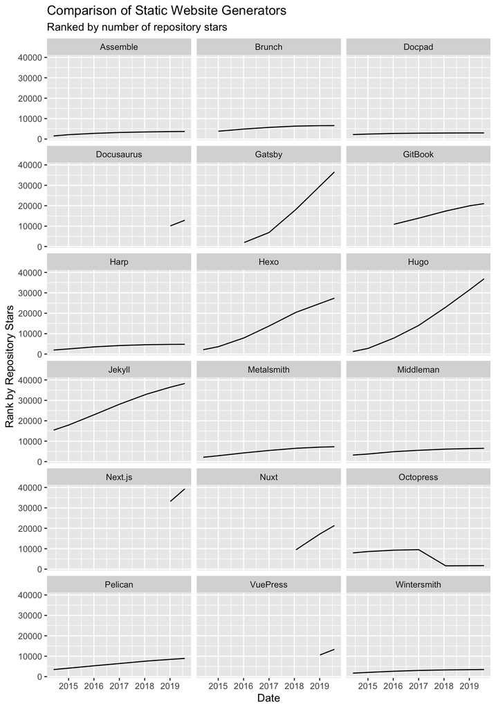

```r
> sg_temp <- select(sg_data, c("Name", starts_with("Stars")))
> order_names <- order(sg_temp$Name)
> sg_temp <-  sg_temp[order_names, ]
>
> # SEE: bit.ly/SO-flip-row-col
> sg_stars <- data.frame(t(sg_temp[-1]))
> colnames(sg_stars) <- sg_temp[, 1]
> rownames(sg_stars) <- sg_quantity[, 1]
> sg_stars <- as_tibble(rownames_to_column(sg_stars, var = "Date"))
> sg_stars$Date <- as.Date(sg_stars$Date)
> sg_stars_long  <- melt(sg_stars, id.vars = "Date",
+                  variable.name = "Staticgen", value.name = "Stars")
>
> p <- ggplot(sg_stars_long, aes(x = Date, y = Stars)) +
+   geom_line(aes(group = Staticgen)) +
+   labs(x = "Date",
+      y = "Rank by Repository Stars",
+      title = "Comparison of Static Website Generators",
+      subtitle = "Ranked by number of repository stars") +
+   facet_wrap(~Staticgen, ncol = 3)
> p
```

One can see that Gatsby, Hexo, Hugo, and Jekyll have a long and ongoing growth curve. But there are also with Next.js and Nuxt two newcomers with very positive developments.

# Bump Chart: Rank changes over time

With this plot, it is difficult to distinguish the relative position of these generators to each other. Instead of absolute values, it is better to use a comparison of the ranking position. This type of plot is called a bump charts. For the following code, I have heavily used explanations and code snippets of various websites:

- [Bump Chart](https://dominikkoch.github.io/Bump-Chart/) by Dominik Koch at [Data Science 42](https://dominikkoch.github.io/).
- [Communicating changes in rank over time](https://datatodisplay.com/blog/chart-design/communicating-changes-rank-time/): bumps charts and slopegraphs by Tim Brock at [Data to Display](https://datatodisplay.com/index.php). Brocks website also features a [stunning interactive demonstration of bump charts](https://datatodisplay.com/examples/co2/). (Click at the country names!!)
- [How to Easily Create a Bump Chart](https://www.statology.org/how-to-easily-create-a-bump-chart-in-r-using-ggplot2/) in R Using ggplot2 at [Statology](https://www.statology.org/).
- [Dog breeds bump chart](https://luisdva.github.io/rstats/dog-bump-chart/) by Luis Verde Arregoitia at [Github.io](https://luisdva.github.io/).

## ggplot2 theme for bump chars

For a better display, all articles suggest creating a specific theme for ggplot2.

```r
> my_theme <- function() {
+
+   # Colors
+   color.background = "white"
+   color.text = "#22211d"
+
+   # Begin construction of chart
+   theme_bw(base_size=15) +
+
+     # Format background colors
+     theme(panel.background = element_rect(fill=color.background, color=color.background)) +
+     theme(plot.background  = element_rect(fill=color.background, color=color.background)) +
+     theme(panel.border     = element_rect(color=color.background)) +
+     theme(strip.background = element_rect(fill=color.background, color=color.background)) +
+
+     # Format the grid
+     theme(panel.grid.major.y = element_blank()) +
+     theme(panel.grid.minor.y = element_blank()) +
+     theme(axis.ticks       = element_blank()) +
+
+     # Format the legend
+     theme(legend.position = "none") +
+
+     # Format title and axis labels
+     theme(plot.title       = element_text(color=color.text, size=20, face = "bold")) +
+     theme(axis.title.x     = element_text(size=14, color="black", face = "bold")) +
+     theme(axis.title.y     = element_text(size=14, color="black", face = "bold", vjust=1.25)) +
+     theme(axis.text.x      = element_text(size=10, vjust=0.5, hjust=0.5, color = color.text)) +
+     theme(axis.text.y      = element_text(size=10, color = color.text)) +
+     theme(strip.text       = element_text(face = "bold")) +
+
+     # Plot margins
+     theme(plot.margin = unit(c(0.35, 0.2, 0.3, 0.35), "cm"))
+ }
```

## Bump Chart for 18 Website Generators

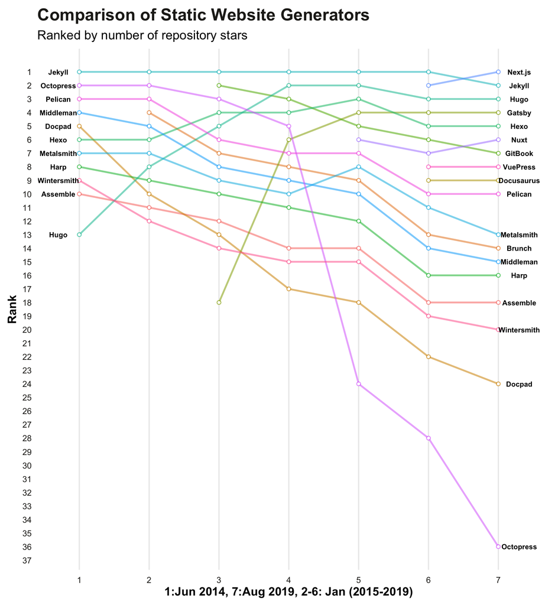

```r
> sg_temp <- select(sg_data, c("Name", starts_with("Rank.Stars")))
> order_names <- order(sg_temp$Name)
> sg_temp <-  sg_temp[order_names, ]
>
> # SEE: bit.ly/SO-flip-row-col
> sg_star_rank <- data.frame(t(sg_temp[-1]))
> colnames(sg_star_rank) <- sg_temp[, 1]
> rownames(sg_star_rank) <- sg_quantity[, 1]
> sg_star_rank <- as_tibble(rownames_to_column(sg_star_rank, var = "Date"))
> sg_star_rank$Date <- as.Date(sg_star_rank$Date)
> sg_star_rank_long  <- melt(sg_star_rank, id.vars = "Date",
+                  variable.name = "Staticgen", value.name = "Rank")
> Archive.Nr <- rep(c(1, 2, 3, 4, 5, 6, 7), 18)
> sg_star_rank_long <<- data.frame(cbind(sg_star_rank_long, Archive.Nr))
>
>
>
> # SEE: https://www.statology.org/how-to-easily-create-a-bump-chart-in-r-using-ggplot2/
> ggplot(sg_star_rank_long, aes(x = as.factor(Archive.Nr), y = Rank, group = Staticgen)) +
+   geom_line(aes(color = Staticgen, alpha = 1), size = 1) +
+   geom_point(aes(color = Staticgen, alpha = 1), size = 2) +
+   geom_point(color = "#FFFFFF", size = 1) +
+   scale_y_reverse(breaks = 1:nrow(sg_star_rank_long)) +
+   scale_x_discrete(breaks = 1:7) +
+   theme(legend.position = 'none') +
+   geom_text(data = sg_star_rank_long %>% filter(Archive.Nr == "1"),
+             aes(label = Staticgen, x = 0.7) , hjust = .5,
+             fontface = "bold",  size = 3) +
+   geom_text(data = sg_star_rank_long %>% filter(Archive.Nr == "7"),
+             aes(label = Staticgen, x = 7.3) , hjust = 0.5,
+             fontface = "bold",  size = 3) +
+   labs(x = "1:Jun 2014, 7:Aug 2019, 2-6: Jan (2015-2019)",
+        y = "Rank",
+        title = "Comparison of Static Website Generators",
+        subtitle = "Ranked by number of repository stars") +
+   my_theme()
```

With this bump chart, one can see which generators are rising in their popularity. These relative developments were hidden by an overall positive trend of static website generators.